# Module 1 - Foundations

TVZ

# Learning Objectives

At the end of this module you should:

1. Be familiar with the following terms of statistical analysis, divided into three general topics:
   1. Statistical
      1. Descriptive Statistics
      2. Inferential Statistics
      3. Statistic
   2. Measurement
      1. Nominal
      2. Ordinal
      3. Interval
      4. Ratio
      5. Discrete variable
      6. Continuous variable
   3. Research
      1. Correlation method
      2. Experimental method
      3. Independent variable
      4. Dependent variable
      5. Confounding variable
2. Understand the different ways of conceptualizing a frequency distribution as an organized display showing where all of the individual scores are located on the scale of measurement. This includes frequency, relative frequency and cumulative frequency distributions.
3. Be able to organize data into frequency distribution histograms and cumulative frequency graphs.
4. Be able to interpret graphical presentations of data.
5. Be able to organize data into a frequency distribution table and interpret data that are presented in a table.
6. Be able to describe locations within a distribution using percentiles and percentile ranks, and to compute percentiles and ranks using interpolation when necessary.
7. Understand the purpose of measuring central tendency and be able to define and compute the measures of central tendency (mean, median, mode).
8. Describe how the mean is affected when a set of scores is modified (a new score is added, a score is removed, or a score is changed).
9. Understand the circumstances in which each measure of central tendency is appropriate.
10. Understand how the three measures of central tendency are related to each other in symmetrical and skewed distributions.
11. Understand the reasons for measuring variability and be able to recognize the difference between distributions with high variability versus distributions with low variability.
12. Be able to define and calculate the range, interquartile range, semi-interquartile range, variance and standard deviation.
13. Understand how each measure of dispersion is influenced by modification to the scores in the dataset.
14. Be able to calculate the sum of squared deviations, variance, and standard deviation for a population.
15. Understand how z-scores provide a precise description of a score’s location in a distribution.
16. Be able to transform measurement values ($X$) into z-scores, and transform z-scores into $X$ values.
17. Be able to perform basic statistical computations in R, including
    1. Uploading a set of data into the R environment.
    2. Subset observations in a dataset and perform simple computations on individual variables within that dataset.
    3. Tabulate frequency information to construct distributions.
    4. Generate histograms and line graphs to visualize data distributions.
    5. Compute quantiles, measures of central tendency, and measures of dispersion.
    6. Transform a set of data into standard (z) scores.

# Preliminary Steps

To get started and to effectively use this R markdown file for studying and practice, you will need to install R and RStudio and upload a dataset into the R environment.

## Data and software

Reading: Navarro [Part II](https://learningstatisticswithr.com/book/part-ii-an-introduction-to-r.html)

Note that the bits in the Navarro text about installing R and RStudio are outdated. See Step 2 below instead.

1. I assume you have a laptop or workstation that belongs to you or that is dedicated to your use. Please contact me if this is not the case.
2. Download R and RStudio by following the directions at https://posit.co/download/rstudio-desktop/.
3. Find a dataset that speaks to you and that you can use all semester. Ideally this dataset will arise from your own research or be obtained from your advisor. If this is impossible at this time, find an interesting dataset from one of the many online repositories available (see Carmen “Resources” for a list of potential sites). This data set should contain at least 5 variables including:
   1. At least one dependent variable and four independent variables;
   2. At least two numeric variables and two categorical variables;
   3. At least one continuous variable; and
   4. At least 100 observation. Avoid data that are longitudinal in nature, including EEG or neuroimaging data. We will not be able to analyze these data properly with the tools in this course.
4. Upload the data into R. Here is a useful guide: https://libguides.chapman.edu/R/import. You may need to load the “foreign” package:

```r
library("foreign")
```

### Aside: Error in library(“foreign”)

Reading: Navarro [Section 4.2](https://learningstatisticswithr.com/book/mechanics.html#packageinstall)

Suppose this happens when you try to load a library:

```
> library("foreign")
Error in library("foreign") : there is no package called ‘foreign’
```

Don’t panic. It means only that you need to install a package. When RStudio opens a Rmd file, it will often detect that an uninstalled package is required and will give you a link to click to install it. If RStudio fails at this or if you need to install a package after the file has been opened, you need only execute something like this:

```r
install.packages("foreign")
```

You might see a lot of red and black text pop up in the console, maybe some indication that code is being compiled, and then a final message like “DONE (foreign)”, followed by the location of the downloaded source packages. Then, as long as no errors were encountered, you should be able to execute the library() function without any trouble.

## Rendering Math

To see the equations that I write in these Rmd files I recommend that you install the tinytex package. (The math is written in the LaTeX markup language.) If you like how the rendered math looks, you might consider installing the full TeX distribution for your own documents. LaTeX can do many, many things, including document preparation (articles, books, theses, etc.), musical and chemical notation, “powerpoints” (which is the beamer package in LaTeX), foreign languages, so much stuff. Get LaTeX [here](https://www.latex-project.org/get/).

```r
# install.packages("tinytex")
library("tinytex")
```

## Uploading data into R

Reading: Navarro [Section 4.5](https://learningstatisticswithr.com/book/mechanics.html#load)

The dataset that I will be using is a subset of the 1980 administration of the General Social Survey (GSS). I selected 6 variables:

1. sibs: number of siblings, from 0 to 20 (OMG)
2. age: age of respondent, from 18 to 89
3. happy: rated level of happiness, where 1=very happy, 2=pretty happy, 3=not too happy
4. health: condition of health, where 1=excellent, 2=good, 3=fair, 4=poor
5. taught: the response to a question about what the “younger generation” should be taught, where 1=taught by elders to do what is right and 2=taught to think for themselves even though elders may disapprove
6. income: the respondent’s income in 1986 dollars, from $755 to $139,297

```r
# My data are in comma separated value (csv) format, with the first line (header) naming the variables:
data <- read.csv("GSS_1980.csv",header=TRUE)

# Take a peek at the first few lines of the dataset:
head(data)
```

|  | X | REALRINC | SIBS | AGE | HAPPY | HEALTH | YOUNGEN |
| --- | --- | --- | --- | --- | --- | --- | --- |
| 1 | 10653 | 8308 | 4 | 62 | 3 | 2 | 1 |
| 2 | 10654 | 11329 | 15 | 77 | 1 | 2 | 2 |
| 3 | 10656 | 16994 | 0 | 28 | 1 | 2 | 2 |
| 4 | 10657 | 139297 | 5 | 24 | 2 | 1 | 1 |
| 5 | 10659 | 32100 | 4 | 63 | 2 | 1 | 1 |
| 6 | 10661 | 56647 | 1 | 62 | 1 | 2 | 2 |

The head() command lets you look at the data to make sure everything is ok. It may not be ok further down, but at least you’ll know what the variables are and you can start to be confident that the data has been uploaded correctly. You can see that there’s a variable “X,” the respondent ID number, that we don’t really need. Let’s delete it.

```r
# We don't need the respondent ID number so we'll delete it:
data$X <- NULL
head(data)
```

|  | REALRINC | SIBS | AGE | HAPPY | HEALTH | YOUNGEN |
| --- | --- | --- | --- | --- | --- | --- |
| 1 | 8308 | 4 | 62 | 3 | 2 | 1 |
| 2 | 11329 | 15 | 77 | 1 | 2 | 2 |
| 3 | 16994 | 0 | 28 | 1 | 2 | 2 |
| 4 | 139297 | 5 | 24 | 2 | 1 | 1 |
| 5 | 32100 | 4 | 63 | 2 | 1 | 1 |
| 6 | 56647 | 1 | 62 | 1 | 2 | 2 |

An easy way to delete a variable from a data frame object (which is what the variable data is) is to assign it the value NULL. You can see now that the variable ID has been removed from the data frame. There are several different ways to do this, you can do it however you want.

Now let’s rename these variables and take a look at the values they take on.

```r
# Give the variables in the dataframe nice names (be careful about order)
names(data) <- c("income","sibs","age","happy","health","taught")


# Let's take a look at a summary of the variables in the dataset:
library('vtable') # This library has some functions for making tables
vt(data) # vt() makes a table that shows information about each variable
```

data

| Name | Class | Values |
| --- | --- | --- |
| income | numeric | Num: 755 to 139297 |
| sibs | integer | Num: 0 to 20 |
| age | integer | Num: 18 to 89 |
| happy | integer | Num: 1 to 3 |
| health | integer | Num: 1 to 4 |
| taught | integer | Num: 1 to 2 |

### Your turn!

I made uploading data look easy here, but for you it might not be. Data wrangling is a huge component of modern data science, so don’t be afraid to ask for help if nothing is working for you. Please consult the R resources provided on Carmen or shoot us an email.

Add a description of the variables in your dataset similar to the one I provided in lines 117-122 above:

> INSERT YOUR WORK HERE

Upload your data now.

```r
# Here is the code I used to upload my data set.
```

# Categorical vs. numerical variables

Reading:

1. Navarro [2.1](https://learningstatisticswithr.com/book/studydesign.html#measurement)-[2.2](https://learningstatisticswithr.com/book/studydesign.html#scales)
2. Howell, Chapter 1
3. Lane et al. [Levels of Measurement](https://www.onlinestatbook.com/2/introduction/levels_of_measurement.html)
4. https://en.wikipedia.org/wiki/Level_of_measurement

Variables are classified according to the amount of information they convey and the kinds of mathematical operations it makes sense to perform on them.

## Nominal or categorical variables

Video about [categorical variables](https://www.khanacademy.org/math/statistics-probability/analyzing-categorical-data/one-categorical-variable/v/identifying-individuals-variables-and-categorical-variables-in-a-data-set)

A nominal or categorical variable *names* or *clusters* observations into groups but does not contain information about magnitude or “how much” that group represents, particularly with respect to comparisons with other groups. It is important to distinguish between nominal and numerical dependent variables, because the way we handle them is very different.

Examples include geographic location (East coast, West coast, Midwest, etc.), area (urban vs. rural), political party (Republican, Democrat, Independent). These kinds of variables can also be called *qualitative*. They are often found in surveys and are used for counting. The information that we get from nominal variables is in terms of the size of each group, or how many observations fall in each category. The mathematical operations that we can perform on nominal data are very limited.

## Numerical variables

Numerical or quantitative variables can be continuous or discrete. Note that nominal variables are always discrete.

The difference between a continuous and a discrete variable rests in the number of values that might be observed. A discrete variable can take on either a finite or *countably infinite* number of possibilities. That is, you can count the number of possible values using natural numbers (1, 2, 3, 4…) even if the total extends to infinity. A continuous variable can take on an *uncountably infinite* number of values. That is, you can’t map all the possibilities onto the set of natural numbers. The real number line is continuous: there are an uncountably infinite number of values between 1 and 2, and an uncountably infinite number of values between any two numbers you might choose. You just can’t count them because between any two values, no matter how close together, there will always be an infinite number of values that you missed.

### Ordinal Variables

Ordinal variables have magnitude but we can’t say much more. A greater value indicates more of the thing measured than lesser values. A preference rating is ordinal: the number of Google stars (1-5) on a restaurant review is ordinal.

### Interval Variables

Interval variables have equal increments between consecutive values but no zero point indicating an absence of magnitude. The classic example of an interval variable is temperature on the Celsius (or Fahrenheit scale). It takes one calorie to raise 1ml of 50C water 1C to 51C, and one calorie to raise the same 1ml of 51C water 1C to 52C. So the intervals between degrees (50C, 51C, 52C) are exactly the same, both physically and numerically (but things get wonky at state boundaries, like 100C). There is no 0C that indicates the absence of any heat (cf. the Kelvin scale).

We don’t have many interval scale variables in the social sciences. One example might be standardized test scores, but you will find people willing to argue that point.

#### Aside: Likert Scale Data

Reading: [Likert scales](https://en.wikipedia.org/wiki/Likert_scale)

How much do you agree that statistics is fascinating? Answer on a 7-point Likert scale, where

1 = Strongly disagree

2 = Disagree

3 = Somewhat disagree

4 = Neither agree nor disagree

5 = Somewhat agree

6 = Agree

7 = Strongly agree

On what scale is this variable? Although many studies treat Likert scale measures as interval (according to the kinds of statistics that are performed on them), they are ordinal. If the scale labels are numerical, however, and the intervals between the labels are equal, then they are interval.

Note: Likert is pronounced “lick-urt,” not “like-urt.” I am old enough to have known him personally, although I didn’t, but there were only [2 degrees of separation](https://en.wikipedia.org/wiki/Six_degrees_of_separation) between us. So don’t argue with me on this one.

### Ratio Variables

Ratio variables have equal intervals and a true zero that indicates the complete absence of the thing being measured. These are usually physical measurements like length, time, weight, and so forth. Income in dollars is measured on a ratio scale, as is body mass, caloric intake, or response time.

### The GSS Dataset

Let’s break down the variables in the GSS dataset according to these characteristics.

Consider first the issue of whether the variables in the GSS dataset are categorical or numerical. Clearly income, age and sibs are numerical. The taught variable is clearly categorical. However, there is some fuzziness in the happy and healthy variables: they could be considered numerical if you believe that level of health or happiness can be ordered given the way the questions were asked. They could also be considered categorical if you don’t believe the questions were pointed enough to provide at least a scale that ordered the two concepts from higher to lower. I’m going to exploit this ambiguity and treat these two variables as either numerical or qualitative, depending on what benefits our discussion at the time.

Next, which variables are continuous or discrete? Sibs is clearly discrete: no one can have 2.5 siblings. Happy and health are discrete because of the structure of the questions: respondents were given a small finite number of options from which to choose on the survey. Income is continuous. Age is continuous (you could be exactly 24.72 years old) but because of how it is measured it must also be considered discrete.

This is an important concept both in the social and physical sciences: variables that are continuous will always appear in a dataset as discrete because of the limitations of our measuring devices. Even the most sensitive measuring device can only return values accurate to some $n^{th}$ decimal place, whatever $n$ happens to be. We will never observe the values that are in between those measurements, not until someone develops a better measuring device.

Here are some R functions that perform rounding and truncation, turning a continuous variable into a discrete one:

```r
age <- 24.72 # years
round(age) # Round to the nearest year
```

```
## [1] 25
```

```r
floor(age) # Your response if someone asks you how old you are
```

```
## [1] 24
```

```r
ceiling(age) # Your response next year when someone asks you how old you are
```

```
## [1] 25
```

Finally, what are the scales of our numerical variables? Income, sibs and age are ratio variables: they have true 0s, an absence of magnitude. You can be 0 years old and have 0 siblings. You can make 0 dollars. If we treat happy and health as numerical they are ordinal variables at most. Neither has a true zero point and neither have equal intervals between values: having a health value of 4 does not mean you have twice the health value of 2.

### Experimental Variables

Before moving on, remember that there are three kinds of experimental variables: dependent, independent, and confounding variables. Dependent variables are the ones that measure the phenomena (behavior) you are trying to understand; independent variables are the ones that you (the experimenter) control and that are suspected to cause changes in the dependent variables; confounding variables are the ones you haven’t thought to control that might influence the dependent variables.

Independent variables can be either fixed or random, with the distinction being that fixed factors do not permit inference to values (levels) outside of those specifically used, whereas random factors are assumed to represent a sample from a potentially larger group. If you control the levels of an independent variable it’s probably fixed; if the variable levels are sampled from a larger range of possibilities it’s random. For example, levels of drug concentrations are fixed; different schools within a district are random.

Because the GSS data is a survey and not the result of a true experiment (surveys are correlational), the independent vs. dependent variable distinction is not meaningful. For this class we can pretend that the variables will take different roles. If we wanted to know something about happiness as a function of the number of siblings, happy would be the dependent variable and sibs would be the (random) independent variable. If we wanted to predict health as a function of age and happiness, health would be the dependent variable and happy and age would be (random) independent variables. The GSS dataset does not contain any fixed factors.

### Your turn!

Describe the variables in your dataset. Which are continuous and discrete? Which are categorical or numerical? On what scales are the numerical variables measured? What are the independent and dependent variables? Which independent variables are fixed and random?

> INSERT YOUR WORK HERE

# Descriptive vs. Inferential Statistics

Readings:

1. Howell Chapter 1
2. Lane et al. [Descriptive statistics](https://www.onlinestatbook.com/2/introduction/descriptive.html) and [Inferential statistics](https://www.onlinestatbook.com/2/introduction/inferential.html)
3. Navarro [Chapter 5](https://learningstatisticswithr.com/book/descriptives.html)

There are two ways of thinking about statistics.

Descriptive statistics is concerned with describing the characteristics of a group or population. Tabulation of populations and economic data such as what you might see in the US Census is an example of descriptive statistics. [Here](https://injuryfacts.nsc.org/) is an example of descriptive statistics (causes of death and injury in the US) together with data visualizations, an important component of the practice of data analytics. Descriptive statistics do not attempt to make inferences about data that are not directly in hand.

Inferential statistics is concerned with determining characteristics of a population based on observations made on a sample from that population. The problem is to *infer* things about the population based on what we observe in the sample. In the social sciences we typically work with *samples* from larger populations, and we wish to say something about the characteristics of the population based on the statistics we compute from the sample.

One important aspect of inference is *prediction*: the extent to which we can say things about one characteristic of a population (say, health) based on knowing a different characteristic of the population (say, number of siblings). In scientific endeavors we generally wish to establish causal relationships between variables (like health and happiness), and inferential statistics can help us to do this. We’ll talk more about this later.

In this section we will focus on descriptive statistics that measure properties of a set of data.

## Definition of a Statistic

Reading: https://en.wikipedia.org/wiki/Statistic

A statistic is any number (or numbers) mathematically derived from a data set. These include not only the statistics with which you may already be familiar, such as the mean, standard deviation, and so forth, but anything you might compute.

It is important that you think of a statistic as a measurement of a dataset, as opposed to the measurements we obtain for an individual in that dataset.

Here’s a novel statistic, computed using the R functions mean() and min():

```r
# The average cubed respondent's age minus the minimum age
mean(data$age^3) - min(data$age)
```

```
## [1] 85276.74
```

What does this statistic represent? Probably nothing meaningful at all. I just made it up. Note that the units are mixed, with years cubed minus years. You can almost always identify bullsh!t by looking at the units of a measurement (e.g., [BMI](https://www.cdc.gov/nccdphp/dnpao/growthcharts/training/bmiage/page5_1.html)). If the units aren’t consistent or if the units don’t combine to make something sensible (e.g., velocity = m/s), how can you assign any meaning to the statistic?

> Diverse weights, and diverse measures, both of them are alike abomination to the LORD. *Proverbs 20:10*

# Distributions

Reading:

1. Navarro [Chapter 6](https://learningstatisticswithr.com/book/graphics.html)
2. Howell Chapter 2 (2.1-2.2)
3. Lane et al. [Graphing distributions](https://www.onlinestatbook.com/2/graphing_distributions/graphing_distributions.html)

Videos:

1. https://www.khanacademy.org/math/statistics-probability/displaying-describing-data
2. https://www.youtube.com/watch?v=_pF7BmysGMA (This one drives me nuts, Dude does NOT KNOW how to pronounce cumulative. It’s KYOO-myoo-lah-tiv.)

It’s time to get more precise. Let our variable of interest (e.g. age) be represented as $X$. We’ll use subscripts to indicate which measured entity (person, animal, etc.) that was measured, so $X_i$ might be the age of the $i^{th}$ respondent in the GSS survey. Our data set is then
$$\{X_1, X_2, \ldots, X_N,\}$$
where $N$ is the number of measurements we obtained.

In addition, there is a set of values that a measurement $X_i$ could take on. This will be called a sample space later. For now, we will write this set of possible values as $\{x_1, x_2, \ldots, x_m\}$. If the variable is continuous we often write the set of possible values as a range, like $[0,1]$ or $[0,\infty)$. The thing to remember is that $X_i$ is a placeholder for a particular individual $i$’s measurement and $x_i$ is the observed value for that measurement.

The word distribution is used to describe either the counts for the values of a categorical variable or how the values of a numeric variable are scattered over the number line. A distribution completely characterizes the behavior of a variable.

### Frequency and relative frequency distributions

Consider the health variable in the GSS data set. We know that the variable can take the values 1, 2, 3, or 4 (so $\{x_1,x_2,x_3,x_4\} = \{1,2,3,4\}$). The frequency of each of these values is the number of respondents who gave each of those possible responses. Using the table() function, we can count these values.

```r
# Note that the $ character lets you pull out a variable from a data frame:
table(data$health)
```

```
##
##   1   2   3   4
## 319 400 132  22
```

This table is the *frequency distribution* of the health variable. We write
$$f(x_i) = \text{the
number of observations in the dataset with the value } x_i.$$

Note that the frequency distribution (and any other data distribution) is a multivariate statistic because we computed the frequencies from the data. (See the definition of a statistic above.)

A *relative* frequency distribution presents this information as proportions instead of raw counts:

```r
cat("Relative Frequency Distribution")
round(table(data$health)/length(data$health),2)

cat("\n") # Insert a blank line, \n is the line break character
cat("Sum of relative frequencies =",
    sum(round(table(data$health)/length(data$health),2)))
```

```
## Relative Frequency Distribution
##    1    2    3    4
## 0.37 0.46 0.15 0.03
##
## Sum of relative frequencies = 1.01
```

The length() function tells you how many elements there are in a vector. The round() function will round a floating point (decimal) number to the nearest desired number of digits, in this case 2. If you add these proportions together they will sum to 1.0. The cat() function concatenates objects together and outputs the result.

We write the relative frequency as
$$\begin{eqnarray*}
p(x_i) & = & \text{the proportion of observations in the dataset
with the value } x_i\\
& = & f(x_i)/N.
\end{eqnarray*}$$

Relative frequency distributions are important for a number of problems, including computing probabilities, but also for comparing two different datasets that have unequal sizes. Let’s split the dataset into two parts, one with the first 50 observations and the remaining 823 in the other.

```r
health.small <- data$health[1:50]
health.large <- data$health[51:length(data$health)]
```

Take note of how I accessed the rows in the health variable. I used square brackets and listed the values by index that I wanted. The notation “n:m” will produce a sequence $n, n+1, n+2, \ldots, m-1, m$.

```r
table(health.small)

cat("\n") # Insert a blank line
table(health.large)
```

```
## health.small
##  1  2  3  4
## 16 23  9  2
##
## health.large
##   1   2   3   4
## 303 377 123  20
```

Does it make sense to compare the raw frequencies in the two samples, to say, for example, that there are fewer “1” responses in the small sample than in the large sample? Of course not, but we can compare the relative frequencies:

```r
round(table(health.small)/length(health.small),2)
cat("\n") # Insert a blank line
round(table(health.large)/length(health.large),2)
```

```
## health.small
##    1    2    3    4
## 0.32 0.46 0.18 0.04
##
## health.large
##    1    2    3    4
## 0.37 0.46 0.15 0.02
```

The relative frequency distributions for the large and small datasets should be similar but not exactly the same. For your data, depending on how the data are ordered, you may see large differences between the relative frequency distributions constructed by taking a small cut of the data off the top, the way it’s done here. If all of the “1” responses are listed first, for example, you might get a small-set relative frequency distribution of $(1.0,0.,0.,0.)$.

Frequency distributions can be plotted as histograms. R has powerful plotting capabilities in the ggplot2 package. My tendency is to plot in raw R (see the plot() and hist() functions below), but ggplot2 is very useful. Here is a cheat sheet for ggplot2 and [here](https://r-statistics.co/Complete-Ggplot2-Tutorial-Part1-With-R-Code.html) is a ggplot2 tutorial.

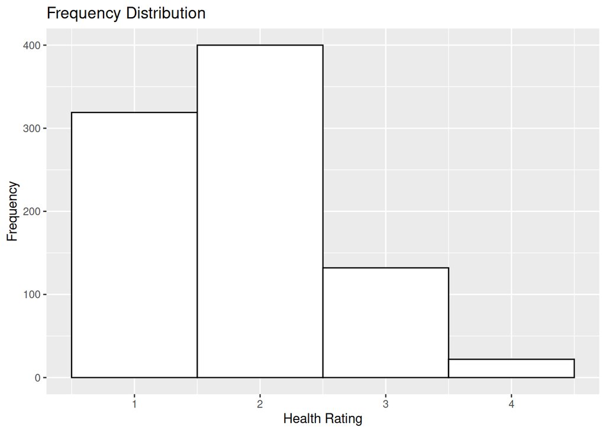

```r
library('ggplot2') # Load the ggplot2 library

# Frequency histogram
ggplot(data=data,aes(x=health)) + geom_histogram(binwidth=1,color="black",fill="white") +
  labs(title="Frequency Distribution", y="Frequency", x="Health Rating")
```

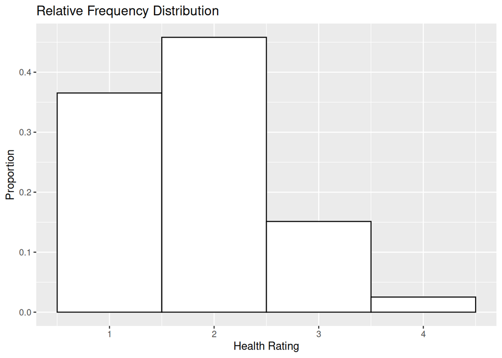

```r
# Relative frequency histogram
ggplot(data=data,aes(x=health)) +
  geom_histogram(aes(y=..density..),binwidth=1,color="black",fill="white") +
  labs(title="Relative Frequency Distribution",
       y="Proportion", x="Health Rating")
```

#### Aside: Histograms vs. Bar Charts

What is the difference between a histogram and a bar chart? While both kinds of displays have quantitive information on the y-axis, a histogram has the values of a quantitative variable on the x-axis and a bar chart has the labeled categories of a nominal variable on the x-axis. So use a bar chart when you’re plotting frequency (or other) information about a nominal variable and a histogram when you’re plotting frequency (or other) information about a numerical variable.

#### Your turn!

Compute the relative frequency distributions of two of the variables in your dataset and plot the relative frequency histograms of those distributions. Keep in mind that there are many, many ways to visualize data distributions and we are covering only a very small number of options here. Challenge: produce some alternative visualizations, such as box-and-whisker plots, stem-and-leaf plots, etc.

> INSERT YOUR WORK HERE

### Cumulative frequencies and relative frequency distributions

Cumulative frequencies describe the number or proportion of observations with values less than or equal to a specific value. We write the cumulative frequency distribution function as
$$F(x_i) = \sum_{j=1}^i f(x_j)$$
and the cumulative relative frequency distribution as
$$P(x_i) = \sum_{j=1}^i p(x_j).$$
These distributions are only meaningful for numerical variables that can be sensibly ordered.

(Do you feel comfortable with summation notation? If not, please go [here](https://www.khanacademy.org/math/ap-calculus-ab/ab-integration-new/ab-6-3/a/review-summation-notation). There are also summation resources on Carmen, and section 2.6 in Howell might be useful.)

We’ll take a look at the distribution of the age variable.

```r
cat("Age Frequency Distribution\n")
table(data$age) # frequency distribution

cat("\n")
cat("Age Cumulative Frequency Distribution\n")
cumsum(table(data$age)) # cumulative frequency distribution
```

```
## Age Frequency Distribution
##
## 18 19 20 21 22 23 24 25 26 27 28 29 30 31 32 33 34 35 36 37 38 39 40 41 42 43
##  2 15 17 18 29 20 30 19 21 36 27 27 28 27 25 34 23 24 28 27 14 13 19 16 13 12
## 44 45 46 47 48 49 50 51 52 53 54 55 56 57 58 59 60 61 62 63 64 65 66 67 68 69
## 18 17 15 10 11 14 15 13 14 11 16 11 13 19 17 14 11  7  8  6  6  8  8  5  4  1
## 70 71 73 76 77 79 80 81 83 87 89
##  3  2  1  1  2  3  1  1  1  1  1
##
## Age Cumulative Frequency Distribution
##  18  19  20  21  22  23  24  25  26  27  28  29  30  31  32  33  34  35  36  37
##   2  17  34  52  81 101 131 150 171 207 234 261 289 316 341 375 398 422 450 477
##  38  39  40  41  42  43  44  45  46  47  48  49  50  51  52  53  54  55  56  57
## 491 504 523 539 552 564 582 599 614 624 635 649 664 677 691 702 718 729 742 761
##  58  59  60  61  62  63  64  65  66  67  68  69  70  71  73  76  77  79  80  81
## 778 792 803 810 818 824 830 838 846 851 855 856 859 861 862 863 865 868 869 870
##  83  87  89
## 871 872 873
```

There are a lot of values in this variable so this is a case where you should perhaps consider a [*grouped* frequency distribution](https://www.mathsisfun.com/data/frequency-distribution-grouped.html). Notice also that the cumulative frequency of the value 89 $F(89) = 873$, the number of observations $N$ in the dataset.

The cumsum() command (cumulative summation) takes as input a vector of values $\{X_1, X_2, \ldots, X_N\}$ and returns the vector $\{X_1, X_1 + X_2, X_1 + X_2 + X_3, \ldots , \sum_{i=1}^{N-1} X_i, \sum_{i=1}^N X_i\}$.

Of most utility is the cumulative relative frequency $P(x_i) = \sum_{j=1}^i p(x_j)$. This distribution is the basis for computing percentiles, percentile ranks, and probabilities. We also call $P(x_i)$ the *empirical distribution function*.

```r
# Relative frequency distribution rounded to 2 significant digits
p <- table(data$age)/length(data$age)
# cumulative frequency distribution rounded to 2 significant digits
P <- cumsum(table(data$age))/length(data$age)

# Print the results rounded to 2 significant digits
cat("Relative Frequencies\n")
round(p,2)
cat("\n")
cat("Cumulative Relative Frequencies\n")
round(P,2)
```

```
## Relative Frequencies
##
##   18   19   20   21   22   23   24   25   26   27   28   29   30   31   32   33
## 0.00 0.02 0.02 0.02 0.03 0.02 0.03 0.02 0.02 0.04 0.03 0.03 0.03 0.03 0.03 0.04
##   34   35   36   37   38   39   40   41   42   43   44   45   46   47   48   49
## 0.03 0.03 0.03 0.03 0.02 0.01 0.02 0.02 0.01 0.01 0.02 0.02 0.02 0.01 0.01 0.02
##   50   51   52   53   54   55   56   57   58   59   60   61   62   63   64   65
## 0.02 0.01 0.02 0.01 0.02 0.01 0.01 0.02 0.02 0.02 0.01 0.01 0.01 0.01 0.01 0.01
##   66   67   68   69   70   71   73   76   77   79   80   81   83   87   89
## 0.01 0.01 0.00 0.00 0.00 0.00 0.00 0.00 0.00 0.00 0.00 0.00 0.00 0.00 0.00
##
## Cumulative Relative Frequencies
##   18   19   20   21   22   23   24   25   26   27   28   29   30   31   32   33
## 0.00 0.02 0.04 0.06 0.09 0.12 0.15 0.17 0.20 0.24 0.27 0.30 0.33 0.36 0.39 0.43
##   34   35   36   37   38   39   40   41   42   43   44   45   46   47   48   49
## 0.46 0.48 0.52 0.55 0.56 0.58 0.60 0.62 0.63 0.65 0.67 0.69 0.70 0.71 0.73 0.74
##   50   51   52   53   54   55   56   57   58   59   60   61   62   63   64   65
## 0.76 0.78 0.79 0.80 0.82 0.84 0.85 0.87 0.89 0.91 0.92 0.93 0.94 0.94 0.95 0.96
##   66   67   68   69   70   71   73   76   77   79   80   81   83   87   89
## 0.97 0.97 0.98 0.98 0.98 0.99 0.99 0.99 0.99 0.99 1.00 1.00 1.00 1.00 1.00
```

From these distributions we can answer questions such as: What proportion of the respondents are between the ages of 20 and 29? or What proportion of the respondents are younger than 50?

```r
cat("Proportions of respondents in their 20s:\n")
sum(p[3:12]) # Add relative frequencies
sum(data$age >=20 & data$age <=29)/length(data$age) # another way
mean(data$age >=20 & data$age <=29) # yet another way

cat("\n")
cat("Proportion of respondents younger than 50:\n")
P[32] # Value of cumulative relative frequency distribution for the value 49
sum(data$age < 50)/length(data$age) # another way
mean(data$age < 50) # yet another way
```

```
## Proportions of respondents in their 20s:
## [1] 0.279496
## [1] 0.279496
## [1] 0.279496
##
## Proportion of respondents younger than 50:
##        49
## 0.7434135
## [1] 0.7434135
## [1] 0.7434135
```

Something to note about the code above is the use of logical (Boolean) operators. These include >=, <=, < and &. Each of these operators returns a value of TRUE or FALSE, which when used in numerical operations like sum() is transformed to 1 or 0 respectively. Please consult Navarro [Section 3.9](https://learningstatisticswithr.com/book/introR.html#logicals) for more examples.

Plotting the cumulative relative frequency distribution is usually done in a stepwise fashion: the proportion of respondents younger than 50 is equal to the proportion younger than 50.5, 50.75, 50.99, etc. This means that the line plot will be a sequence of flat lines with jumps at the integer values.

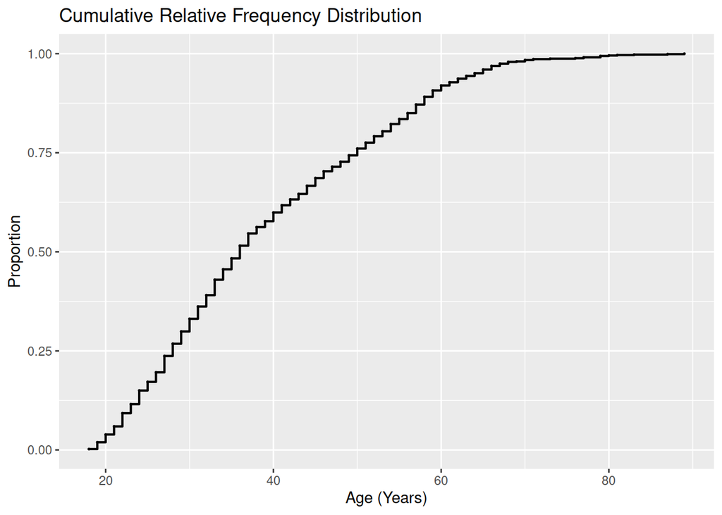

```r
# Create a data frame that holds the cumulative relative frequency distribution of data$ages.
ages <- data.frame(age=as.numeric(names(P)),proportion=P)
ggplot(ages, aes(x = age, y = proportion)) +
  geom_step(linewidth = .75, direction = "hv") +
  geom_point(size = .25) +
  labs(title = "Cumulative Relative Frequency Distribution",
       x = "Age (Years)",
       y = "Proportion")
```

#### Your turn!

Compute the cumulative relative frequency distributions of two of the variables in your dataset and plot them.

> INSERT YOUR WORK HERE

### Percentiles

Readings:

1. https://www.statisticshowto.com/probability-and-statistics/percentiles-rank-range/
2. https://www.mathsisfun.com/data/percentiles.html
3. https://statisticsbyjim.com/basics/percentiles/
4. Howell Chapter 2 (2.11)

Video: https://www.khanacademy.org/math/statistics-probability/modeling-distributions-of-data/percentiles/v/calculating-percentile

It will be useful to talk about percentiles before we continue on to discuss measures of centrality and dispersion. You should already have an intuitive understanding of percentiles, especially if you have grown up with standardized tests. The results of these tests are usually reported as your percentile rank. For the 2023-2024 administration of the [ACT](https://www.act.org/content/dam/act/unsecured/documents/MultipleChoiceStemComposite.pdf), a composite score of 26 had a percentile rank of 85: 26 was higher than 85% of the scores.

Remember that percentiles have values on the original scale of the measurement (years, shoe sizes, IQ points, height, etc.), but that percentile ranks are always either percentages (numbers between 0 and 100) or proportions (numbers between 0 and 1).

There are many legitimate ways to compute percentiles and percentile ranks. R gives you a choice between *nine* different possible methods to compute percentiles.

```r
# A type=1 computation returns the inverse of the empirical distribution function
cat("Type 1\n")
quantile(data$age,probs=seq(0,1,by=.1),type=1)

# A type=4 computation returns a linear interpolation of the empirical distribution function
cat("\n")
cat("Type 4\n")
quantile(data$age,probs=seq(0,1,by=.1),type=4)
```

```
## Type 1
##   0%  10%  20%  30%  40%  50%  60%  70%  80%  90% 100%
##   18   23   27   30   33   36   41   46   53   59   89
##
## Type 4
##   0%  10%  20%  30%  40%  50%  60%  70%  80%  90% 100%
## 18.0 23.0 27.0 29.9 33.0 36.0 40.8 46.0 53.0 59.0 89.0
```

Sometimes the different types will return the same values but often not. When the dataset is as large as mine (873 observations) all of the different methods will tend to produce the same results. Smaller datasets will exhibit more differences.

We refer more generally to quantiles when we move away from percentiles. Percentile ranks vary from 0% to 100% in 1% increments. Quantiles cut a distribution into ranges of equal proportions, such as deciles (10%), quartiles (25%), and so forth. If we partition a distribution into $q$ different regions with equal proportions of the data in each, then a value $x$ is the kth q-quantile of the variable $X$ if
$$Pr(X < x) \le k/q \text{ or } Pr(X \ge x) \ge
1 - k/q,$$
where $Pr(\text{condition})$ is the probability that $\text{condition}$ is true in the dataset, or the proportion of observations in the dataset that satisfy $\text{condition}$.

#### Advanced: General Formula for a Percentile

A percentile $P_{\%}$ (like $Q_1$, $Md$ or $Q_3$) specifies the score below which a certain percentage ($\%$) of scores fall. On the picture of a cumulative relative frequency distribution, a percentile is a point on the abscissa (x-axis) and its percentile rank $P_R$ is the height of the cumulative relative frequency at that point.

Most of the time linear interpolation (“type=4” in the quantile() function) is employed for percentiles. Before doing anything, *you must order the measurements from smallest to largest*. Let

1. $N$ be the number of scores,
2. $X_{ll}$ be the [*real lower limit*](https://dictionary.apa.org/real-limit) of the interval that contains the desired percentile,
3. $f_i$ be the number of scores in the interval that contains the desired percentile,
4. $i$ be the size of the interval (e.g., 1 for ungrouped data), and
5. $\sum f_b$ be the number of scores below $X_{ll}$.

Then
$$P_{\%} = X_{ll} + i \left(\frac{N (P_R/100) - \sum f_B}{f_i} \right).$$

For example, given an *ordered* sample of values $X=\{4,5,6,6,7,7,7,7,8,8,9,10\}$, let’s determine the $90^{th}$ percentile $P_{90}$. For this sample, $N=12$ and $i=1$. Because $.9 N = 10.8$, we know that $P_{90}$ falls between the $10^{th}$ and $11^{th}$ score. The $10^{th}$ score is 8 and the $11^{th}$ score is 9. So $X_{ll}=7.5$, the real lower limit of 8. There are $\sum f_b=8$ scores below $X_{ll}$, and there are $f_i=2$ scores in the interval containing $P_{90}$. Using the equation,
$$P_{90} = 7.5 + 1 \left( \frac{12(90/100) - 8}{2} \right) = 7.5 + 1.4 =
8.9.$$

Using a little algebra, you can also turn this equation around to find the percentile rank $P_R$ of any score $P_{\%}$.

### Your turn!

Compute the deciles of the distributions of two of the variables in your dataset. If you change the method you use, do the values change? If they do, can you explain why?

> INSERT YOUR WORK HERE

# Descriptive Statistics

Readings:

1. Navarro [Chapter 5](https://learningstatisticswithr.com/book/descriptives.html#missing) (Sections 5.1-5.5)
2. Lane et al. [Summarizing distributions](https://www.onlinestatbook.com/2/summarizing_distributions/summarizing_distributions.html)
3. Howell Chapter 2 (2.7-2.8)

Videos: https://www.khanacademy.org/math/statistics-probability/summarizing-quantitative-data

Above we defined a statistic as any quantity that is computed from a dataset. (Frequency distributions are multivariate statistics consisting of counts of variable values.)

Statistics are typically divided into those that measure where the middle of a distribution is (central tendency) and those that measure how spread out the values are from that middle (dispersion).

Keep in mind that statistics computed from a sample of data are generally used as *estimates* of a *population parameter*, the population from which the sample was drawn. We’ll talk about this concept a bit later when we discuss inferential statistics, in which the goal is to infer something about the population from which a dataset (a *sample*) was obtained.

Also, try to think of a descriptive statistic as a measure of a group of values $\{X_1, X_2, \ldots, X_N\}$, in the same way that $X_i$ is a measure of an individual $i$.

## Measures of Central Tendency

Readings:

1. Navarro [Section 5.1](https://learningstatisticswithr.com/book/descriptives.html#centraltendency)
2. Howell Chapter 2 (2.7)
3. Lane et al. [Measures of Central Tendency](https://learningstatisticswithr.com/book/descriptives.html#centraltendency)

Video: https://www.khanacademy.org/math/statistics-probability/summarizing-quantitative-data

There are three primary statistics that measure where the middle of a distribution of a numeric variable is: the mean, median and mode. Hopefully you’re familiar with these already. There are many others (https://en.wikipedia.org/wiki/Central_tendency#Measures), some of which are programmed into the R base package and others that you might have to compute yourself using other R functions.

### The arithmetic average (mean)

We use the mean a lot; it’s the most popular measure of central tendency. This is because it has some pretty amazing mathematical properties that make it convenient for almost everything we might want to do with a measure of central tendency. Computing a mean is easy in R.

```r
# R has built in functions for several measures of central tendency, others are in other packages, some you have to do yourself.
mean(data$age) # Arithmetic average
sum(data$age)/length(data$age) # Arithmetic average computed from its definition
```

```
## [1] 39.24628
## [1] 39.24628
```

#### Properties of the Mean

The mean can be used for ordinal or higher scales. (Some purists might argue that it should only be used for interval or ratio scales, however). There are three important properties of the mean:

1. The mean is very sensitive to extreme scores (see the Properties of the Median below).
2. The mean minimizes the sum of squared deviations of the values $\{X_1, X_2, \ldots, X_N\}$ around the mean $\overline{X}$. This “sum of squares” is given by
   $$\sum_{i=1}^N \left(X_i -
   \overline{X} \right)^2.$$
   We’ll talk about this property again when we talk about variance.
3. The mean is the geometric “balance point” of a distribution. (See Lane et al. https://www.onlinestatbook.com/2/summarizing_distributions/balance.html.)

Consider again the histogram of the health ratings frequency distribution. Imagine that the bars are placed on a ruler and your goal is to balance the loaded ruler on the point of a finger. We would want to put our finger precisely at 1.84.

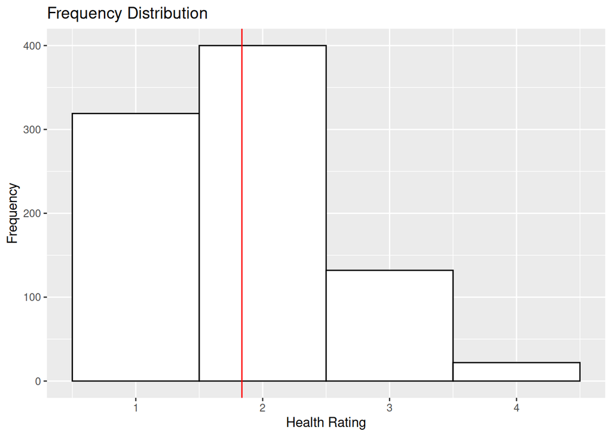

```r
ggplot(data=data,aes(x=health)) + geom_histogram(binwidth=1,color="black",fill="white") +
  labs(title="Frequency Distribution", y="Frequency", x="Health Rating") +
  geom_vline(xintercept=mean(data$health), color="red") +
  geom_text(x=mean(data$health),y=620, label=paste("Mean = ",round(mean(data$health),2),sep=''))
```

There is a mathematical way of describing this property. Let’s define a “deviation score” as the extent to which any score differs from the mean, $D_i = X_i - \overline{X}$. If the mean is the balancing point, it means that for every negative deviation $-D_i$, there must be some positive deviations somewhere ($D_j$ or even $D_j + D_k$) that balance it out, or make it zero. That is, the sum of all deviation scores in a sample must equal zero. In other words, the mean balances the scores. We can easily show this:

$$\begin{eqnarray*}
\sum_{i=1}^N (X_i-\overline{X}) & = & \sum_{i=1}^N X_i-
\sum_{i=1}^N
\overline{X} \\
& = & \sum_{i=1}^N X_i- N \overline{X} \\
& = & \sum_{i=1}^N X_i- N \frac{\sum_{i=1}^N X_i}{N} \\
& = & \sum_{i=1}^N X_i- \sum_{i=1}^N X_i \\
& = & 0.
\end{eqnarray*}$$

### The Median

The median is the value in the dataset below which 50% of the observations fall (and conversely above which 50% of the observations fall). Another way to refer to the median is as the 50-th percentile (see Percentiles above). The formal definition of the median is the value $m$ that satisfies
$$P(X < m) \ge 0.5 \text{ and } P(X \ge m) \ge
0.5.$$

R has a median() function:

```r
median(data$age)
```

```
## [1] 36
```

#### Properties of the Median

The median can be used for ordinal or higher scales of measurement. Because the median reflects the proportion of scores that are below (i.e., less in magnitude) than a particular value, order information is implied in the sample. There are several important properties of the median:

1. The median is not always unique. There is often a range of values that satisfy the definition of the median.
2. The median is mathematically very difficult to work with. Computing the median requires that the data be sorted from lowest to highest values and the computation takes place on the indices (the $i$ of $X_i$) rather than the values $\{X_1, X_2, \ldots, X_N\}$ themselves.
3. The median is more *robust* than the mean because it isn’t very sensitive to extreme scores in the dataset, whereas the mean can be pulled so far off center by these kinds of scores that it is no longer very useful.

To examine the robustness problem we can generate fake (“simulated”) data.

```r
fake.age <- round(rnorm(15,mean=15,sd=1.5)) # age of students in a summer ceramics class
```

The rnorm() function generates random numbers from a normal distribution with the specified mean and standard deviation (see below).

Imagine your local arts college offers summer courses for high school students. Fifteen students enroll and their ages distribution looks like this:

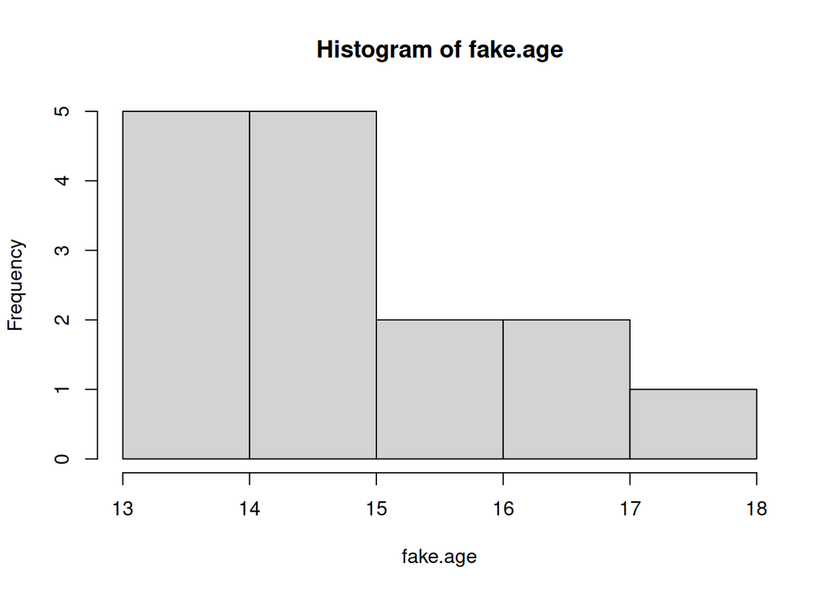

```r
hist(fake.age)
```

```r
# Let's store the mean and median in separate variables
mean.1 <- round(mean(fake.age),2)
median.1 <- median(fake.age)
```

Now let’s see what happens if we add a 65-year-old grandmother who is interested in ceramics and doesn’t mind being in a classroom with high school students. The c() function concatenates values into a set of numbers:

```r
fake.age <- c(fake.age,65)

# Let's store the new mean and median in separate variables
mean.2 <- round(mean(fake.age),2)
median.2 <- median(fake.age)
```

The addition of an older person in the class increases the mean from 15.13 to 18.25, while the median is unchanged: 15 to 15.

(Note: every time you reknit this Rmd file these numbers will change because the rnorm() function is going to give you a different set of values.)

The problem with the mean after the older person joins is that it is now greater than 94% of the observations, making it hard to say that the mean represents the “middle” of the distribution in any sense of the word.

Thus we say that the median is robust to outliers while the mean is not. Rememberthat our goal in measuring central tendency is to come up with a number that characterizes all of the scores in a sample. If the mean is pulled up to the point where it is greated than all of the scores but one, that is not a very good indication of central tendency. In the presence of extreme scores, the mean will be pulled toward those extremes, whereas the median is relatively unaffected. This fact means that when extreme scores are present, the median may be the better measure of central tendency.

### The Mode

The mode is simply the most frequently occurring score in a sample. It corresponds to the “bumps” in a frequency distribution.

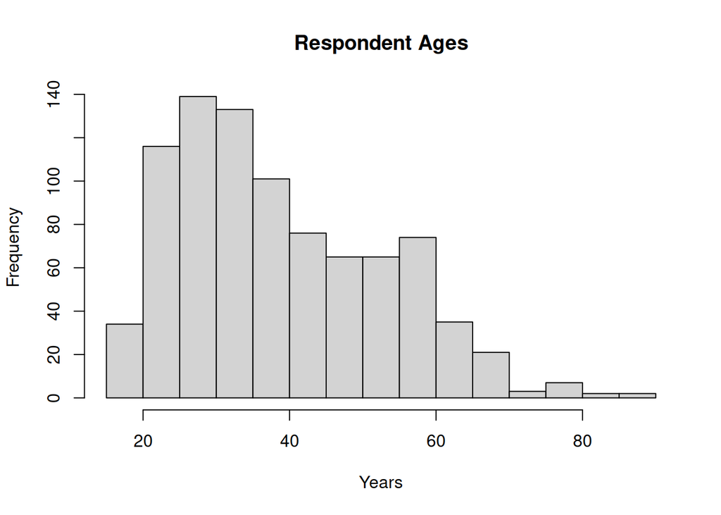

```r
hist(data$age, main="Respondent Ages",xlab="Years")
```

#### Properties of the Mode

There are a few things to remember about the mode. The mode is

1. Not necessarily unique;
2. Unstable; and
3. The only appropriate measure of central tendency for nominal data.

With regard to nominal variables, there really isn’t a “center” for the distribution of a nominal variable, which is why only the mode is the only appropriate measure of central tendency.

Examine the histogram of GSS respondent ages above. This is an example of a bimodal distribution. There are two “bumps,” one for younger respondents (around 30) and one for older (around 60). There are more scores around 30, however, so that is going to be the unique mode for this dataset. But you can imagine that there could be several modes in a dataset.

The mode is surprisingly tricky to compute not only because it isn’t necessarily unique (there could be more than one) but also because how you compute it will depend on the scale of the measurement and whether it’s continuous or discrete. For these reasons, R does not have a function to compute the mode; you’ll have to do it by hand. There are a few strategies for computing the mode, and here is one:

```r
# Tally all the unique values in the data
values <- unique(data$age)

# Compute a frequency distribution (see also table())
tab <- tabulate(match(data$age, values))

# Find the value of the variable with the highest frequency count
mode <- values[tab == max(tab)]
cat("Mode = ",mode)
```

```
## Mode =  27
```

This approach computes the modal age as 27.

### Relationships Between the Mode, Median, and Mean

Where the mode, median and mean are located relative to each other depends on the shape of the frequency distribution. We saw already that if the distribution is symmetric and unimodal, the three measures of central tendency are equal. Consider, however, what happens for distributions of different shapes.

The sibs variable follows a positively skewed distribution. We say that it is positively skewed because the upper tail is stretched out toward positive infinity.

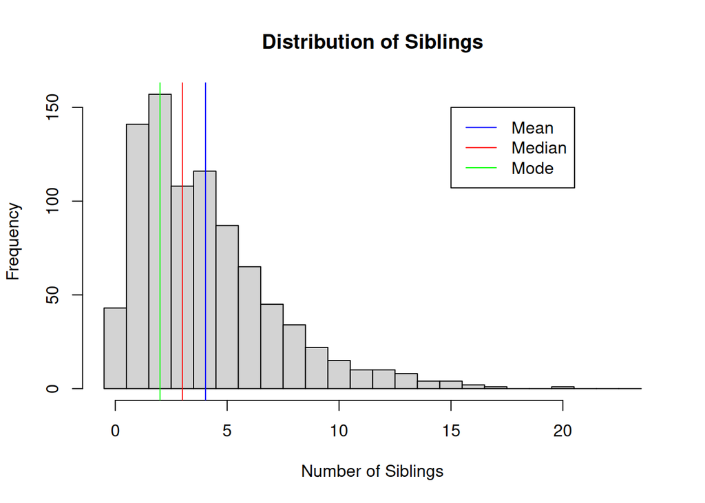

```r
mean.sibs <- mean(data$sibs)
median.sibs <- median(data$sibs)
mode.sibs<-as.numeric(names(which.max(table(data$sibs)))) # another way to compute the mode

#the hist() function is a quick and dirty way to plot a histogram
hist(data$sibs,breaks=seq(-.5,23.5,by=1),
     main="Distribution of Siblings",xlab="Number of Siblings")
abline(v=c(mean.sibs,median.sibs,mode.sibs),col=c("blue","red","green"))
legend(15,150,c("Mean","Median","Mode"),lty=1,col=c("blue","red","green"))
```

Notice what this skewness has done to the three measures of central tendency. The mean $\overline{X}$, because it is most sensitive to the extreme scores in the positive tail, has been pulled toward those scores the most. The mode is, as always, located at the highest point of the frequency distribution. The median is in between the mean and the mode.

Take a look now at a negatively skewed distribution. Because none of the variables in the GSS dataset are negatively skewed I’ll create a new variable, which is the difference between the maximum number of siblings and the number of siblings for each respondent.

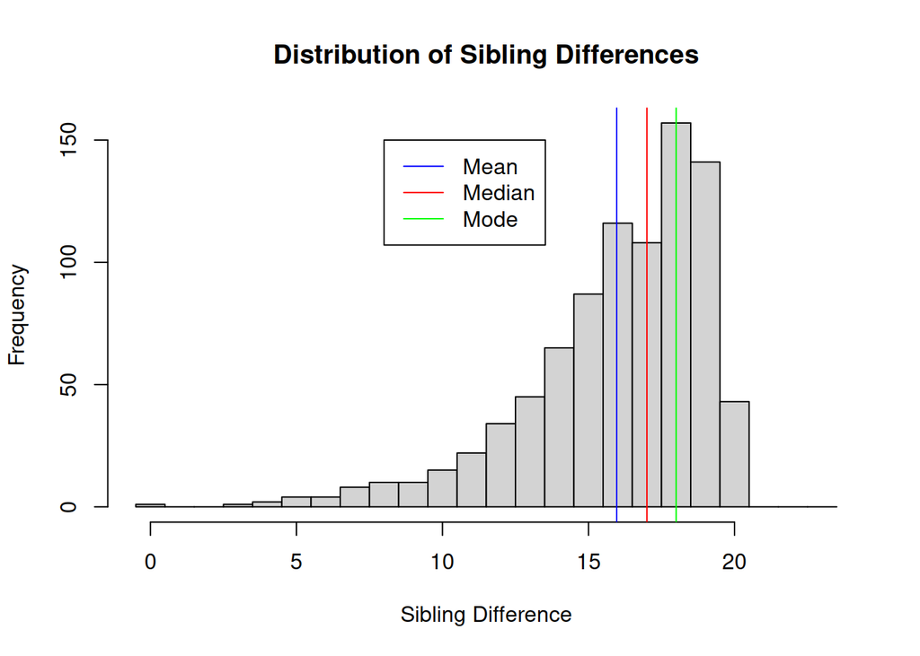

```r
# Create new variable
diff.sib <- max(data$sibs) - data$sibs

# Compute measures of central tendency
mean.diff <- mean(diff.sib)
median.diff <- median(diff.sib)
mode.diff <-as.numeric(names(which.max(table(diff.sib)))) # another way to compute the mode

# Plot the frequency histogram
hist(diff.sib,breaks=seq(-.5,23.5,by=1),
     main="Distribution of Sibling Differences",xlab="Sibling Difference")
abline(v=c(mean.diff,median.diff,mode.diff),col=c("blue","red","green"))
legend(8,150,c("Mean","Median","Mode"),lty=1,col=c("blue","red","green"))
```

Now the tail of the distribution points toward the negative numbers and the ordering of the mean, median and mode is reversed. The mean has been pulled down toward those negative numbers and the median is between the mean and the mode.

Now look at the next frequency distribution, which is based on simulated data.

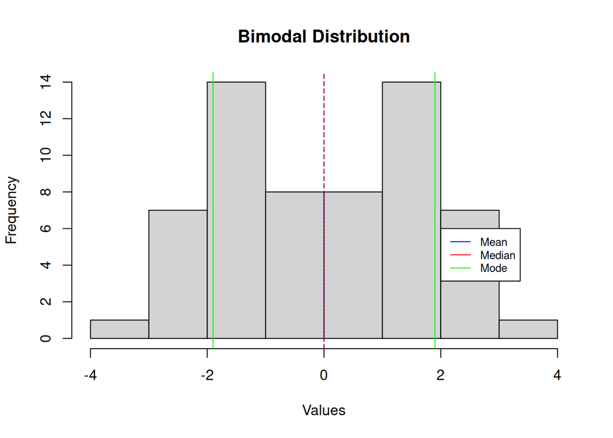

```r
bimodal <- rnorm(30,-1.5,1) # Draw 30 samples from a normal distribution with mean -1 and sd 1
bimodal <- c(bimodal,-bimodal) # Augment the samples with the negatives of the sampled values

mean.bimodal <- mean(bimodal)
median.bimodal <- median(bimodal)
mode.bimodal<-as.numeric(names(which(table(round(bimodal,1))==max(table(round(bimodal,1))))))

# The hist() function gets annoyed if there are values outside the requested plotting range.  The
# lim variable computes the nearest 0.5 value less than the minimum; this is not something
# that you need to worry about usually and is a function of me not using ggplot.

lim <- floor(2*(min(bimodal)-.5)+.5)/2 # nearest 0.5 value less than the minimum
hist(bimodal,breaks=seq(lim,-lim,by=1),
     main="Bimodal Distribution",xlab="Values")
abline(v=c(mean.bimodal,median.bimodal,mode.bimodal),
       col=c("blue","red","green","green"),lty=c(2,3,1,1))
legend(2,6,c("Mean","Median","Mode"),lty=1,col=c("blue","red","green"),cex=.75)
```

This bimodal distribution is symmetric. This means that the mean equals the median and both are located at 0, the very center of the distribution. However, because the distribution is bimodal, the modes have been shifted away from the center point to either end. (Run this chunk a few times to get a feel for how this works; sometimes the distribution won’t look bimodal because of how the data are grouped for the histogram.)

The only time when all three measures of central tendency equal each other is when the distribution is symmetric and unimodal.

### Other measures of central tendency

Here are some other measures of central tendency: the harmonic mean, the geometric mean, and the midrange:

```r
1 / mean(1 / data$age) # Harmonic mean
```

```
## [1] 34.67423
```

```r
exp( mean( log(data$age) ) ) # Geometric mean
```

```
## [1] 36.87245
```

```r
(min(data$age) + max(data$age)) / 2 # Midrange
```

```
## [1] 53.5
```

These measures are used for a number of different kinds of variables. The harmonic mean is used for rate data and the geometric mean is commonly used for growth data. The midrange is highly unstable and rarely used.

### Your turn!

Compute the mean, median and model for two of the variables in your dataset. Plot the frequency distribution histogram of one of them (using either hist() or ggplot()) and mark the values of these measures on the histogram. Comment on the shape of the frequency distribution and the ordering of the three measures of central tendency.

> INSERT YOUR WORK HERE

## Measures of dispersion

Readings:

1. Navarro [Section 5.2](https://learningstatisticswithr.com/book/descriptives.html#var)
2. Howell Chapter 2 (2.8)
3. Lane et al. https://www.onlinestatbook.com/2/summarizing_distributions/variability_ov.html

The best way to think about dispersion is with respective to some measure of central tendency. If the central tendency is the middle or “most characteristic score,” a measure of dispersion tells us how much the sample deviates from the most characteristic score, or the extent to which the measure of central tendency fails.

Consider the following distributions:

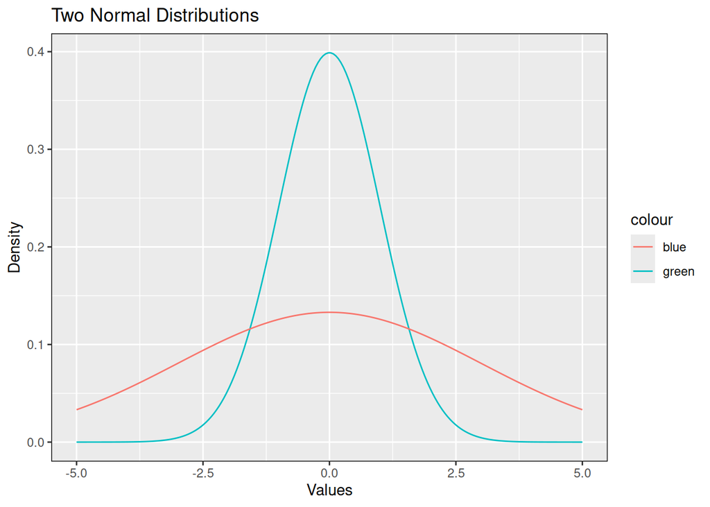

```r
# Create a dataframe containing some points along the x-axis (z) and two normal
# distributions (y.1 and y.2)
z <- seq(-5,5,length=200)
normals <- data.frame(z =z,
                         y.1 =dnorm(z,mean=0,sd=1),
                         y.2 =dnorm(z,mean=0,sd=3))

# Plot the two distributions
ggplot(data=normals,aes(x=z)) +
  geom_line(data=normals,aes(y=y.1,color="green")) +
  geom_line(data=normals,aes(y=y.2,color="blue")) +
  labs(title="Two Normal Distributions",x="Values",y="Density") +
  theme(panel.border=element_rect(color="black",fill=NA))
```

Although the two distributions have the same measure of central tendency (the means, medians and modes are all equal to 0), they are very different in the extent to which that measure of central tendency is accurate. The narrow, peaked distribution is less disperse or less variable than the low, fat distribution. In this section, we will present a number of statistics that allow us to measure the different degrees of dispersion in a dataset.

## The Range

A very simple measure of dispersion is the range. It is defined as the highest versus the lowest score in a sample. Consider the sibs variable. The range is the difference between the largest number of respondent siblings and the smallest.

```r
r.s <- range(data$sibs) # The range function returns the minimum and maximum values in the dataset
cat("The range of sibs is",r.s[2]-r.s[1],".")
```

```
## The range of sibs is 20 .
```

If we examine another sample that is more disperse, like the ages variable, the range will be larger.

```r
r.a <- range(data$age)
cat("The range of age is",r.a[2]-r.a[1],".")
```

```
## The range of age is 71 .
```

Examining the range is a quick and easy way to evaluate dispersion.

## The Interquartile Range

The interquartile range is defined as the difference between the $75^{th}$ and $25^{th}$ percentiles. The $75^{th}$, $50^{th}$ and $25^{th}$ percentiles are often referred to as “quartiles” because they cut the sample into four equal parts. For the quartiles $Q_1, Q_2, Q_3$, where $Q_1$ is the 25th percentile, $Q_2$ is the median or 50th percentile, and $Q_3$ is the 75th percentile, $IQR = Q_3 - Q_1$.

Let’s compute the IQR for the sibs variable. There are (at least) two ways to do this in R.

```r
# R has an IQR function
iqr.sibs.1 <- IQR(data$sibs)

# Compute the quartiles explicitly
q.sibs <- quantile(data$sibs,c(.25,.75))
iqr.sibs.2 <- q.sibs[2]-q.sibs[1]

cat("The two ways of computing the IQR give the same answer.  Using the IQR function we obtained",iqr.sibs.1,".
    From the 25% and 75% quantiles we obtained",q.sibs[2],"-",q.sibs[1],"=",iqr.sibs.2,".")
```

```
## The two ways of computing the IQR give the same answer.  Using the IQR function we obtained 4 .
##     From the 25% and 75% quantiles we obtained 6 - 2 = 4 .
```

## The Semi-Interquartile Range

The semi-interquartile range is simply the half-width of the interquartile range, or $SIQR = \frac{Q_3 - Q_1}{2} = \frac{IQR}{2}$.

```r
cat("The semi-IQR is",IQR(data$sibs)/2)
```

```
## The semi-IQR is 2
```

## The Variance

Probably the most important measure of dispersion is the variance. The variance is concerned with deviation scores, defined above as $D_i = X_i - \overline{X}$. To remember what the variance measures, you should keep in mind that, in terms of the measure of central tendency, deviation scores are errors: the extent to which we failed to capture a particular score $X_i$ by assuming that the measure of central tendency was a good approximation to it. For the variance, the measure of central tendency is always the mean $\overline{X}$.

Because the mean $\overline{X}$ is a balance point, we can’t look at average deviation to measure dispersion. Average deviation will always equal zero because
$$\sum_{i=1}^N (X_i - \overline{X}) =
0.$$
However, we could transform the deviation scores in some way so that the sum of the transformed deviations does not equal zero, and look at the average of those. There are a number of ways you could transform the scores. One is by taking the mean of the absolute deviation $|D_i|$, defined by
$$\frac{\sum_{i=1}^N \left| X_i - \overline{X}
\right|}{N}.$$
Because the absolute deviation is always positive, the sum of absolute deviations won’t add to zero and the mean will not be zero.

For the variance $S^2$, the deviations are squared and then averaged. The definition of the variance is therefore
$$S^2 = \frac{\sum_{i=1}^N
(X_i-\overline{X})^2}{N},$$
and is sometimes called the mean squared deviation.

The statistic $S^2$ is written as a square to remind us that the variance must always be a positive number. This is a good way to check your work. If you ever compute a variance and find out that it’s negative, you know that you’ve done something wrong.

Note also that $S^2$ is sometimes called the *population variance*. The *sample variance* is defined as
$$s^2 = \frac{\sum_{i=1}^N (X_i -
\overline{X})^2}{N-1}.$$
We will soon talk about the difference between these two variances.

Make sure that you can compute the variance of a (small) dataset by hand. The steps are to:

1. Compute the mean $\overline{X} = \sum_{i=1}^N X_i/N$.
2. Compute the set of deviation scores $D_i = X_i - \overline{X}$.
3. Square each deviation score $D_i^2$.
4. Compute $S^2$ as the mean of the squared deviation scores $\sum_{i=1}^N D_i^2/N$.

In R we use the var() function:

```r
var(data$age)
```

```
## [1] 196.1881
```

```r
cat("The variance of the age of the GSS respondents is ",var(data$age),".\n")
```

```
## The variance of the age of the GSS respondents is  196.1881 .
```

```r
# Let's do it following the 4 steps above:
mean.age <- mean(data$age) # Step 1
dev.age <- data$age - mean.age # Step 2
sq.dev.age <- dev.age^2 # Step 3
MSS <- mean(sq.dev.age) # Step 4
cat("The variance of the age of the GSS respondents is ",MSS)
```

```
## The variance of the age of the GSS respondents is  195.9634
```

Hang on! Are those variances different? Yes, they are. Why is that?

The variance computed by var() is the sample variance, so the sum of squares is divided by $N-1$ instead of $N$. R only computes the variance with the $N-1$ denominator, and for most purposes that is in fact the variance measure that we use. To see this, we can convert the MSS by multiplying by $N$ (cancelling out the denominator $N$) and dividing again by $N-1$.

```r
N <- length(data$age)
MSS*N/(N-1)
```

```
## [1] 196.1881
```

## The Standard Deviation

R has the sd() function which computes the *sample* standard deviation.

```r
sd.age <- sd(data$age)
sd.age
```

```
## [1] 14.00672
```

```r
# Compare:
sqrt(MSS*N/(N-1))
```

```
## [1] 14.00672
```

The standard deviation must always be positive, like the variance. Because the standard deviation is defined on the original scale of the variable, the standard deviation gives a measure of dispersion that can be more intuitively interpreted.

### Why $N-1$?

Reading: Howell, pp. 45-47

We just called $S^2$ the population variance and $s^2$ the sample variance. The distinction rests in how we want to use the variance measure. If we only want to describe the data we have, we use $S^2$: it’s a descriptive measure. If we want to estimate an unknown population variance we use $s^2$: it’s an inferential measure. (Yes, the population variance is the one that has nothing to do with the population. Frustrating, but it’s because we assume that the data from which we compute $S^2$ *are* the population.)

Why do we use these two measures, which are almost exactly the same thing, differently? It’s because $s^2$ is an *unbiased* estimate of the population variance $\sigma^2$: on average it will equal the variance of the population from which the data were sampled. The alternative $S^2$ is biased: on average it is not equal to the population variance. This is easy to demonstrate.

```r
bignum <- 10000 # Number of samples
N <- 30 # Sample size
sigma <- 15

# Generate bignum samples of size N
samples <- matrix(rnorm(bignum*N,0,sigma),ncol=10)
s2 <- apply(samples,1,var)

# The next two lines use a quick "computational" method to compute S^2
S2.means <- rowMeans(samples)
S2 <- rowMeans(samples^2) - S2.means^2

# Compare
cat("The mean of s^2 is ",mean(s2),".\n")
```

```
## The mean of s^2 is  224.2272 .
```

```r
cat("The mean of S^2 is ",mean(S2),".\n")
```

```
## The mean of S^2 is  201.8045 .
```

```r
cat("The true variance is ",sigma^2,".\n")
```

```
## The true variance is  225 .
```

You can see that because the numerator of $S^2$ is always divided by a number $N$ that is just a little bit too big, on average the value of $S^2$ will be a little bit too small if our goal is to get as close to the population variance as possible.

The value $N-1$ is called the *degrees of freedom* of the numerator of the variance (the sum of squared deviations). This term is used because the estimate of the population variance is computed using another estimate, the sample mean $\overline{X}$. By using an estimate of the population $\mu$ rather than the actual value $\mu$, we “penalize” ourselves by taking away a degree of freedom.

## Your Turn!

For your dataset, compute the range, IQR, SIQR, variance and standard deviation for two of your variables. Briefly describe what these measures of dispersion say about your variables.

> INSERT YOUR WORK HERE

## The Principle of Least Squares

The second property of the mean (above) is that it minimizes the sum of squared deviation scores around a distribution’s center. This property is stated another way: the mean is a least squares estimator.

So first, estimator of what? Think of the mean as your best guess for any score in the dataset. The mean $\overline{X}$ estimates or predicts any score $X_i$. Of course it isn’t going to be perfect: $\overline{X}$ will be a bit wrong for each $X_i$.

Imagine that you have to pay some amount of money that is proportional to the extent to which a measure of central tendency $C$ fails to predict an $X_i$, and these penalties are to be added over all the observations in a dataset. The sum of the penalties is called the loss, and the way that they are computed is according to a loss function. If the loss function is $\sum_{i=1}^N (X_i - C)^2$, the sum of squared deviations around $C$, we want to pick $C$ so that we pay as little as possible.

Remember from above that the mean of the respondents’ ages is 39.25. Let’s compute the value of the sum of squares loss function $L(C) = \sum_{i=1}^N (X_i - C)^2$ and see what $C$ must equal to minimize your loss.

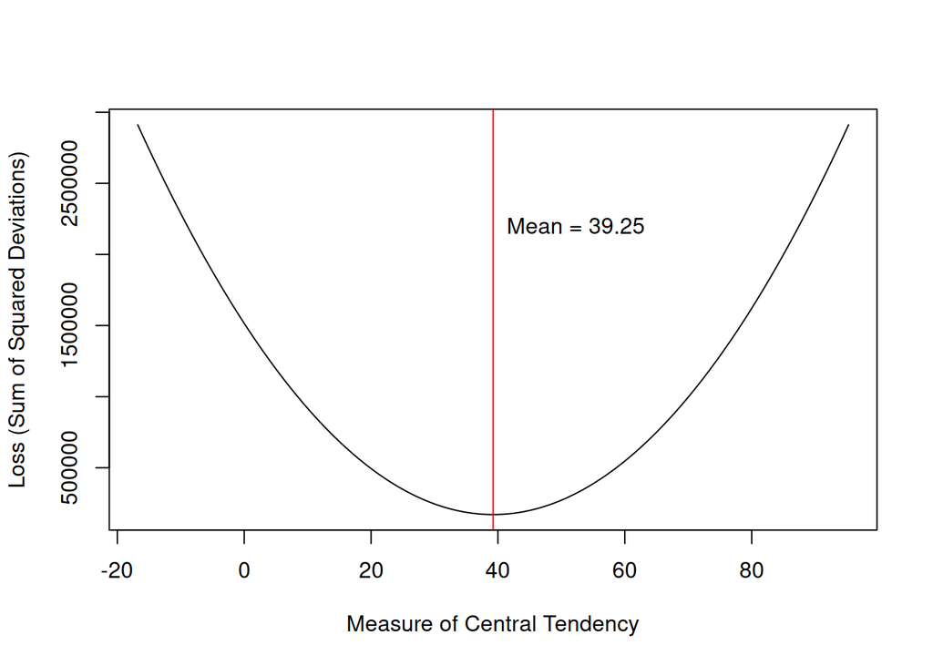

```r
# Define values of C for a good range around the mean age
# We'll take 200 points between the mean plus and minus 4 standard deviations
C <- seq(mean.age-4*sd(data$age),mean.age+4*sd(data$age),length=200)

# Compute the loss function for each value of C
loss <- vector()
for (i in 1:200)
  loss[i] <- sum((data$age-C[i])^2)

# Plot the loss as a function of where we take the "middle" of the distribution
plot(C,loss, type='l',xlab="Measure of Central Tendency",ylab="Loss (Sum of Squared Deviations)")
abline(v=mean.age,col='red')
text(mean.age,.75*max(loss),paste("Mean = ",round(mean.age,2),sep=''),pos=4)
```

The loss is a parabolic function of what we choose to be the measure of central tendency, and the vertex of the parabola is located exactly at the mean age.

We can show formally that $\overline{X}$ minimizes the loss function using either algebraic manipulation of the sum of squares or using calculus.

### Advanced: Using Algebra

Consider the loss function $L(C)$, the loss incurred by choosing the value $C$ as the measure of central tendency:
$$L(C) = \sum_{i=1}^N (X_i-C)^2.$$

Now, we will perform a little trick. We will add zero to $X_i-C$, but in a special way. It should be obvious that $X_i-C = X_i-C+0$, and that $\overline{X}-\overline{X}=0$. Therefore, $X_i-C = X_i-C+\overline{X}-\overline{X}$, and reorganizing terms we can write this as $[X_i-\overline{X}]-[C-\overline{X}]$. Inserting this into our loss function,
$$L(C) = \sum_{i=1}^N ([X_i-\overline{X}]-[C-\overline{X}])^2.$$

The next step is expand the squared term, but we need to do it carefully and keep the terms in square brackets together:
$$L(C) = \sum_{i=1}^N
([X_i-\overline{X}]^2-2[X_i-\overline{X}][C-\overline{X}]+[C-\overline{X}]^2).$$

Now distribute the sum across the separate terms:
$$L(C) = \sum_{i=1}^N [X_i-\overline{X}]^2 - \sum_{i=1}^N
2[X_i-\overline{X}][C-\overline{X}] + \sum_{i=1}^N[C-\overline{X}]^2 .$$

As far as the sum is concerned, $C$ and $\overline{X}$ are constants. Therefore we can simplify this expression to
$$L(C) = \sum_{i=1}^N [X_i-\overline{X}]^2 -
2[C-\overline{X}]\sum_{i=1}^N[X_i-\overline{X}] + N[C-\overline{X}]^2.$$

This last equation is what tells us that $\overline{X}$ minimized the sum of squares loss function. What you need to notice is that regardless of the values of $C$ and $\overline{X}$, the value of $[C-\overline{X}]^2$ must always be greater than 0 because it is squared. There is no way to add something positive to $L(\overline{X})$ and make it get smaller. The smallest that $L(C)$ can be, then, is when the thing being added to $L(\overline{X})$ is equal to zero, and that only happens when $C=\overline{X}$, that is, when we use the mean $\overline{X}$ as the measure of central tendency.

### Advanced: Using Calculus

You may remember from calculus that you find function extrema by setting the first derivative of the function with respect to the variable on the x-axis and setting the result equal to zero. Solving for the x-axis variable gives us the location of the extrema. (This is a much easier way to demonstrate the least squares property than using algebra.)

The first step is the derivative:
$$\begin{eqnarray*}
\frac{dL(C)}{dC} & = & \frac{d}{dC} \sum_{i=1}^N (X_i - C)^2 \\
& = & \sum_{i=1}^N \frac{d}{dC} (X_i - C)^2 \\
& = & \sum_{i=1}^N 2 (-1) (X_i - C).
\end{eqnarray*}$$

Now we will simplify the derivative and set it equal to 0:
$$\sum_{i=1}^N 2 (-1) (X_i - C) = -2 \left[ \sum_{i=1}^N X_i - NC \right]
= 0.$$

This implies that $\sum_{i=1}^N X_i = NC$, or, dividing each side by $N$, $\overline{X} = C$ is the location of the minimum.

### Relative Merits of Each Measure of Dispersion

The standard deviation is the most widely used measure of dispersion because of its useful mathematical properties. However, it is not robust to outliers and therefore may not be appropriate for characterizing dispersion for skewed distributions. In contrast, the semi-interquartile range $SIQR$ is robust. Both the standard deviation and the semi-interquartile range are used for quantitative data.

The range is very simple. However, it is very unstable. One outlier can change the value of the range by a great deal. Also, it depends on sample size. The larger the sample, the larger the possibility of obtaining an outlier score, and the larger the range will become.

## Things to Remember

It’s worth repeating at least two things:

1. In the same way that $X_i$ is a measure of an individual $i$, measures of central tendency like the mean $\overline{X}$ are measures of the dataset: the most characteristic score. If we obtain another, different dataset that measure of central tendency will be different, indicating that the middle of the distribution of the new dataset is different from the old one.
2. A measure of central tendency can be viewed as the “best” predicted value for all the observations of the variable. Measures of dispersion are a way of characterizing the extent to which the predictions fail. A loss function quantifies the extent of this failure.

## Skewness and Kurtosis

Reading:

1. Navarro [Section 5.3](https://learningstatisticswithr.com/book/descriptives.html#skewandkurtosis)
2. Howell Chpater 2 (2.5)
3. Lane et al. https://www.onlinestatbook.com/2/summarizing_distributions/shapes.html

Video: https://www.khanacademy.org/math/statistics-probability/displaying-describing-data/comparing-features-distributions/v/shapes-of-distributions

Skewness is a measure of the asymmetry of a distribution. Kurtosis is a measure of how sharply peaked the distribution is.

Kurtosis is measured relative to a perfect bell curve (normal distribution). If a distribution is more peaked than a normal distribution, we say it is leptokurtic. If it is less peaked, we say it is platykurtic. (The mnemonics I use to remember these terms are ``platy is flat and lepto leaps up.’’ Your mileage may vary.)

The descriptive statistics for skewness $Sk$ and kurtosis $Kur$ are
$$Sk = \frac{\sum_{i=1}^N (X_i-\overline{X})^3 / N}{S^3},$$
and
$$Kur = \frac{1}{S^4} \frac{\sum_{i=1}^N (X_i - \overline{X})^4}{N} - 3,$$
where $S$ is the standard deviation. The statistic $Sk$ is positive (or negative) when the distribution is positively (or negatively) skewed. $Kur$ is negative when the distribution is platykurtic and positive when it is leptokurtic.

In real life, you won’t see too much discussion of kurtosis. It is a difficult characteristic of a distribution to measure accurately. Furthermore, there are several different ways to measure skewness and kurtosis. The formulas I just provided are sometimes referred to as Fisher’s skewness and kurtosis, after [the statistician](https://en.wikipedia.org/wiki/Ronald_Fisher) who first presented them. Like the standard deviation, Fisher’s skewness and kurtosis are not robust to the presence of outliers and are appropriate only for quantitative data.

The R library ‘e1071’ has functions to compute skewness and kurtosis. These functions can compute these measures in different ways. The default method (“type=3”) uses the Fisher formulas.

```r
library('e1071')
Sk <- skewness(data$age,type=3)
Kur <- kurtosis(data$age,type=3)
cat("Skewness = ",Sk)
```

```
## Skewness =  0.6449755
```

```r
cat('\n')
```

```r
cat("Kurtosis = ",Kur)
```

```
## Kurtosis =  -0.3045403
```

The next code chunk computes the skewness and kurtosis “by hand”:

```r
# Computing skewness and kurtosis from scratch
Sk <- mean(dev.age^3)/sd(data$age)^3
Kur <- mean(dev.age^4)/sd(data$age)^4 - 3
cat("Skewness = ",Sk)
```

```
## Skewness =  0.6449755
```

```r
cat('\n')
```

```r
cat("Kurtosis = ",Kur)
```

```
## Kurtosis =  -0.3045403
```

### Your Turn!

Compute the Fisher skewness and kurtosis for two of your quantitative variables. Contrast these measures to the shapes of their frequency distributions. Are the measures consistent with what you can see in the distributions? Are they consistent with how the measures of central tendency are ordered?

> INSERT YOUR WORK HERE

## What is an Outlier?

We’ve seen above (the ages of the folks in the ceramics class) an example of the effects of an outlier. These are scores that are so different from the rest of the measurements that they don’t seem to belong. The decision we need to make is whether or not we should remove such measurements from a dataset. Such a decision should not be made lightly: it is too easy for an experimenter’s biases to influence such decisions and result in biased data. Data, no matter how strange-looking, are valuable and important, and unless you can be absolutely certain that a measurement is in some way inaccurate you should be very hesitant to throw it away.

There are several ways to make this decision objectively (but “objective” guidelines do not completely protect the data from biases). One common method is to see how many standard deviations the score is from the mean and to discard observation that fall beyond a certain prespecified number.

```r
# Set an upper limit on age of 2.5 standard deviations
cutoff <- mean.age + 2.*sd.age

# What proportion of observations are outliers according to this criterion?
p.outliers <- mean(data$age>cutoff)
cat("A cutoff of 2.0 standard deviations for respondents' age is ",round(cutoff,2),".\n")
cat("The proportion of the dataset to be removed as outliers is ",round(p.outliers,2),".")
```

```
## A cutoff of 2.0 standard deviations for respondents' age is  67.26 .
## The proportion of the dataset to be removed as outliers is  0.03 .
```

### Your Turn!

For two of your variables, determine if there are any outliers in the data.

> INSERT YOUR WORK HERE

# Standard Scores

Reading:

1. Navarro [Section 5.6](https://learningstatisticswithr.com/book/descriptives.html#zscore)
2. Howell Chapter 2 (pp. 53-54)

Video: https://www.khanacademy.org/math/statistics-probability/modeling-distributions-of-data

Suppose you are in a class of 10 people. You all took a test and the scores (in percent) were as follows:
$$X =
\{15,17,20,20,21,22,22,23,30,35\}.$$
The mean test score is $\overline{X} = 22.5$ and the standard deviation is $S = 5.61$. When you call your mother to tell her you got a 30 on the exam, there are several ways to tell her how you did:

1. “Ma! I got a 30 on the exam!”
2. “Ma! I scored 7.5 points over the mean!”
3. “Ma! I scored [7.5/5.61=] 1.34 standard deviations over the mean!”

The first bit of information is likely to make her angry. However, you could go with the second bit of information, the deviation score, which at least tells her that you weren’t the only person to fail the test. The last way of telling her, in terms of standard deviations over the mean, gives not only that you were higher than the mean but also that you were much higher than the mean given the dispersion of test scores in the class.

An R function that standardizes a set of scores is scale():

```r
z.age <- scale(fake.age) # scale() also returns the center (mean) and scale (sd) used for standardization
round(mean(z.age),2)
```

```
## [1] 0
```

```r
round(sd(z.age),2)
```

```
## [1] 1
```

```r
# Compare to standardizing by hand:
m.age.2 <- mean(fake.age)
sd.age.2 <- sd(fake.age)
z.age.2 <- (fake.age - m.age.2)/sd.age.2

cbind(Age=fake.age,z.age,z.age.2)
```

```
##       Age                 z.age.2
##  [1,]  15 -0.25904845 -0.25904845
##  [2,]  14 -0.33875566 -0.33875566
##  [3,]  15 -0.25904845 -0.25904845
##  [4,]  13 -0.41846288 -0.41846288
##  [5,]  17 -0.09963402 -0.09963402
##  [6,]  15 -0.25904845 -0.25904845
##  [7,]  14 -0.33875566 -0.33875566
##  [8,]  13 -0.41846288 -0.41846288
##  [9,]  17 -0.09963402 -0.09963402
## [10,]  15 -0.25904845 -0.25904845
## [11,]  14 -0.33875566 -0.33875566
## [12,]  18 -0.01992680 -0.01992680
## [13,]  16 -0.17934123 -0.17934123
## [14,]  16 -0.17934123 -0.17934123
## [15,]  15 -0.25904845 -0.25904845
## [16,]  65  3.72631231  3.72631231
```

## Special characteristics of standard (z) scores

Z-scores are “standardized in the sense that they have mean 0 and standard deviation 1. (You might have heard z-scores referred to as”normalized,” which is an alternative label. Do *not* make the mistake of thinking that this means that z-scores are normally distributed.)

```r
mean(z.age)
```

```
## [1] -1.626303e-17
```

```r
sd(z.age)
```

```
## [1] 1
```

Note that the mean of the z.age variable computed by the mean() function is not exactly 0, but it is a tiny number (1e-13cm is the width of a proton). This tiny nonzero value is due to rounding error.

The frequency distribution of z-scores is a shifted and rescaled version of the frequency distribution of the original variable.

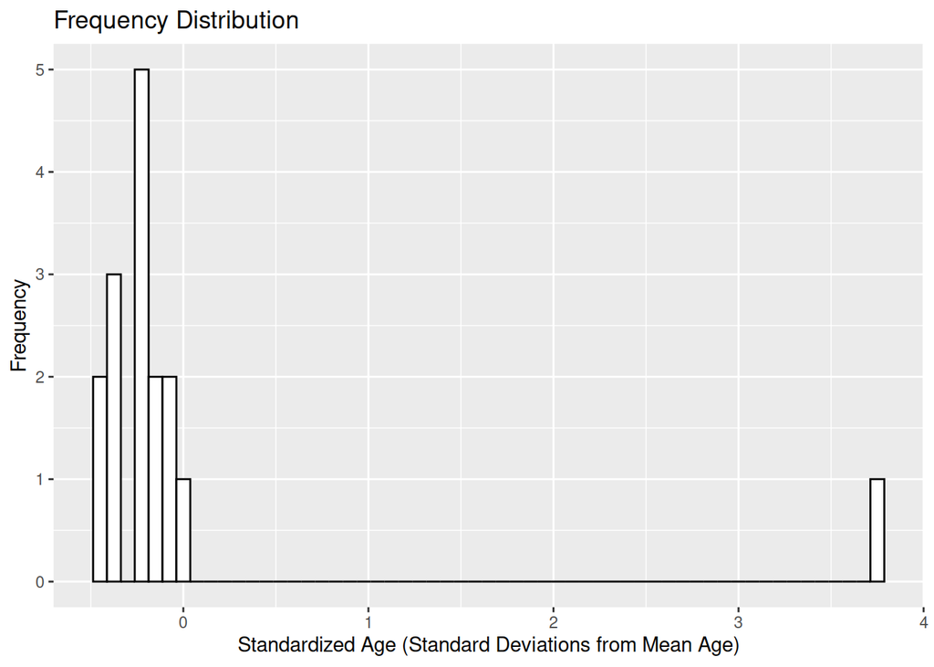

```r
ggplot(data=NULL,aes(x=z.age)) + geom_histogram(binwidth=.075,color="black",fill="white") +
  labs(title="Frequency Distribution", y="Frequency", x="Standardized Age (Standard Deviations from Mean Age)")
```

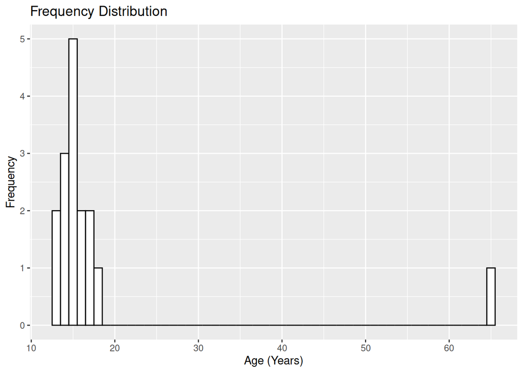

```r
ggplot(data=NULL,aes(x=fake.age)) + geom_histogram(binwidth=1,color="black",fill="white") +
  labs(title="Frequency Distribution", y="Frequency", x="Age (Years)")
```

The two histograms above show the frequency distributions of the original Age variable in the fake.age dataset and the standardized Age variable z.age.

It is important to understand that a set of z-scores always has mean 0 and standard deviation 1, regardless of the mean and standard deviation of the original variable. It is straightforward to show that this must be true for any dataset.

### Advanced: The mean of z-scores

Using the definitions of the mean $\overline{X} = \sum_{i=1}^N X_i/N$ and the z-score $Z_i = (X_i - \overline{X})/S$, we want to compute $\overline{Z}$. Remember also that the sum of deviation scores $D_i = X_i - \overline{X}$ is always equal to 0 because the mean $\overline{X}$ is the balance point of the frequency distribution.

$$\begin{eqnarray*}
\overline{Z} & = & \frac{1}{N} \sum_i Z_i \\
& = & \frac{1}{N} \sum_i \left(
\frac{X_i-\overline{X}}{S} \right) \\
& = & \frac{1}{N} \frac{1}{S} \sum_i (X_i -
\overline{X}) \\
& = & \frac{1}{N} \frac{1}{S} \sum_i D_i
\\
& = & \frac{1}{N} \frac{1}{S} (0) = 0.
\end{eqnarray*}$$

### Advanced: The variance of z-scores

Now we need to use the definition of the variance $S^2 = \sum_{i=1}^N (X_i - \overline{X})^2/N$.

$$\begin{eqnarray*}
S_Z^2 & = & \frac{\sum_{i=1}^N (Z_i - \overline{Z})^2}{N} \\
& = & \frac{\sum_{i=1}^N (Z_i - 0)^2}{N} \\
& = & \frac{\sum_{i=1}^N Z_i^2}{N} \\
& = & \frac{\sum_{i=1}^N
\left(\frac{X_i-\overline{X}}{S}\right)^2}{N} \\
& = & \frac{\frac{1}{S^2} \sum_{i=1}^N
(X_i-\overline{X})^2}{N} \\
& = & \frac{1}{S^2} S^2 = 1.
\end{eqnarray*}$$

## Your Turn!

Convert two of your variables to z-scores and plot their histograms.

> INSERT YOUR WORK HERE